# Capstone project

Matthew Rees

4 November 2014

# Text Prediction Application

# Introduction

Over the past decade, there has been a dramatic increase in the usage of electronic devices for email, social networking and other activities. Errors typing on such devices are far from uncommon, and can have considerable implications concerning the efficient use of such devices for communication.

Text prediction requires estimation of the next character or word given a string of the input history. This may represent a useful solution to the problem of mistyping words.

In this project we aim to develop a text predictive algorithm derived from large data sets composed of different source material blogs, twitter etc. to develop an application.

# Task 1 - Data acquisition and cleaning

Data was obtained from HC corpora (www.corpora.heliohost.org). It contains data from four languages (english, german, finish and russian) of blogs, news and twitter data.

**Tasks to accomplish:**

The aim of this initial report is to perform an exploratory analysis of text data from HC corpora, providing a basic understanding of; - The distribution of words - The relationship between the words - The differences in frequencies of words - The presents of word pairs and triplets in the data.

This aim required the accomplishment of three primary tasks: - Exploratory analysis.

- Data cleaning
- Profanity filtering - removing profanity and other words you do not want to predict.

# 1. Data processing

```r
library(wordcloud)
library(qdap)
library(stringr)
library(RWeka)
library(tm)
```

Analysis of the corpora database; - Basic statistics of the data set

```r
corpus.b <- readLines("~/Desktop/Capstone Project/final/en_US/en_US.blogs.txt")
nlines.b <- length(corpus.b)
nwords.b <- sum(unlist(sapply(corpus.b, str_count, pattern = " "))) + nlines.b

corpus.n <- readLines("~/Desktop/Capstone Project/final/en_US/en_US.news.txt")
nlines.n <- length(corpus.n)
nwords.n <- sum(unlist(sapply(corpus.n, str_count, pattern = " "))) + nlines.n

corpus.t <- readLines("~/Desktop/Capstone Project/final/en_US/en_US.twitter.txt")
nlines.t <- length(corpus.t)
nwords.t <- sum(unlist(sapply(corpus.t, str_count, pattern = " "))) + nlines.t

df.lines <- data.frame(file = factor(c("blogs", "news", "twitter")), count = c(nlines.b, nlines.n, nlines.t))

df.words <- data.frame(file = factor(c("blogs", "news", "twitter")), count = c(nwords.b, nwords.n, nwords.t))

df.comb <- data.frame(File = factor(c("Blogs", "News", "Twitter")), Count_of_lines = c(nlines.b, nlines.n, nlines.t), Count_of_words = c(nwords.b, nwords.n, nwords.t))
df
```

[output not shown]

These statistics can be better assessed with a plot demonstrating the number of lines and of words in the three text files. .

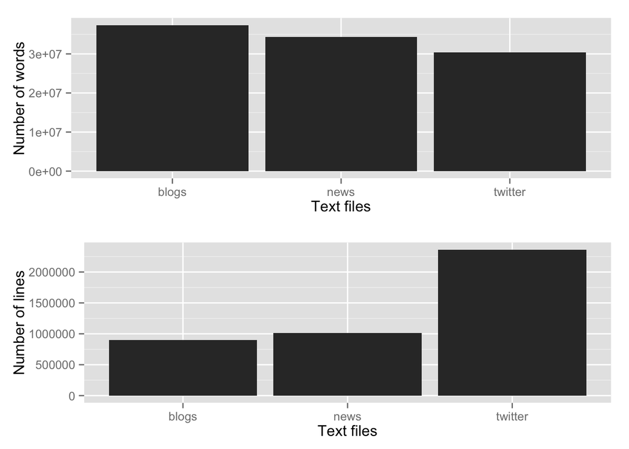

# Data cleaning

The *stringi* and *tm* packages were used to transform the text into a format conducive to tokenisation, which is the next step in the project. The following steps were undertaken….

- Transform unknown characters
- Convert all characters to lower space
- Replace i with I
- Remove punctuation except for “.”, and “’”, which are essential for structure and understanding of the sentence.
- Remove white spaces
- Remove dot spaces
- Remove numbers
- Split lines by the postitioning of dots

```r
library(stringi)

directory_source <- DirSource("~/Desktop/Capstone Project/final/en_US", encoding = "UTF-8")

corpus <- Corpus(directory_source,readerControl=list(reader=readPlain))
# Convert all letering to lower case
corpus.clean <- tm_map(corpus, function(x) stri_trans_tolower(x[[1]]))

# Replacing 'i' with 'I', using the tm package, this was simpler to perform through multiple substitutions than through a single line of code.
corpus.clean <- tm_map(corpus.clean, function(x) gsub("^i ", "I ", x))
corpus.clean <- tm_map(corpus.clean, function(x) gsub("^i'", "I'", x))
corpus.clean <- tm_map(corpus.clean, function(x) gsub(" i ", " I ", x))
corpus.clean <- tm_map(corpus.clean, function(x) gsub(" i'", " I'", x))
corpus.clean <- tm_map(corpus.clean, function(x) gsub(".i ", ". I ", x))
corpus.clean <- tm_map(corpus.clean, function(x) gsub(".i'", ". I'", x))

# Remove punctuation with exception of . and ''' using the tm package.
corpus.clean <- tm_map(corpus.clean, function(x) gsub("[!?,.]+", ".", x))
corpus.clean <- tm_map(corpus.clean, function(x) gsub('[])(;:#%$^*\\~{}[&+=@/"`|<>_]+', "", x))

# Remove white spaces, using the tm package.
corpus.clean <- tm_map(corpus.clean, stripWhitespace)

# Remove dot spaces for later split
corpus.clean <- tm_map(corpus.clean, function(x) gsub(" \\.", ".", x))
corpus.clean <- tm_map(corpus.clean, function(x) gsub("\\. ", ".", x))

# Remove numbers, using the tm package.
corpus.clean <- tm_map(corpus.clean, removeNumbers)

# Splitting by dots
corpus.clean <- tm_map(corpus.clean, function(x) strsplit(x, "\\."))
```

Ultimately this process will convert a blog such as …

```r
head(corpus$ en_US.blogs.txt)
```

```
## [1] "In the years thereafter, most of the Oil fields and platforms were named after pagan “gods”."
## [2] "We love you Mr. Brown."
## [3] "Chad has been awesome with the kids and holding down the fort while I work later than usual! The kids have been busy together playing Skylander on the XBox together, after Kyan cashed in his $$$ from his piggy bank. He wanted that game so bad and used his gift card from his birthday he has b…
## [4] "so anyways, i am going to share some home decor inspiration that i have been storing in my folder on the puter. i have all these amazing images stored away ready to come to life when we get our home."
## [5] "With graduation season right around the corner, Nancy has whipped up a fun set to help you out with not only your graduation cards and gifts, but any occasion that brings on a change in one's life. I stamped the images in Memento Tuxedo Black and cut them out with circle Nestabilities. I emb…
## [6] "If you have an alternative argument, let's hear it! :)"
```

Into the following…

```r
head(corpus.clean$ en_US.blogs.txt)
```

```
## [[1]]
## [1] "in the years thereafter"
## [2] "most of the oil fields and platforms were named after pagan “gods”"
```

# Profanity filtering

A decision was made not to exclude profanities until the prediction component of the project, due to the impact this may have on the understanding of the sentence.

# Tokenisation

This is the next step in the capstone project, although the code has not yet been written, however it will begin with segmenting text into words based on the presence of spaces, and will be followed by the production of unigram, bigram and trigram with an Ngramtokenizer in the RWeka package.

Fin.